# Sampled Living Planet Index (Canada)

Indicators and Assessments Unit, ZSL

10/08/2021

## Sampled Living Planet Index (Canadian pops)

The Living Planet Index is a composite biodiversity index consisting of over 22,000 population trends from over 4,000 species. It tracks the average change in relative abundance in each year in these populations.

It has a hierarchical structure:

- The global index, composed of
  - Three ‘system’ indices: Terrestrial, Freshwater and Marine, each containing..
  - Multiple ‘Realm’ indices (e.g. Afrotropics, Neotropics, Palearctic), with multiple..
  - Taxonomic indices for taxonomic classes (Aves, Mammalia, Fishes, Reptiles)..
  - Within each taxo-regional group, each species index may contain multple..
  - Population trends

In some cases the number of species trends available for a specific region may be disproportionate to the number of species within that region. For this reason the Living Planet Index is also weighted - with a taxo-regional group being weighted according to the species richness of that group in that region. For example, if birds represent 30% of vertebrate species in the Palearctic, then the palearctic birds index will have a weighting of 0.3 and other palearctic indices will have a total weight of 0.7.

Some regions have few populations or species and one interesting question is how many species or populations are needed to accurately capture wildlife trends in a give region. This could be further explored by stratifying species according to intrinsic (size, range) or extrinsic factors (threat, land-use).

The functions below all for the creation of living planet indices from source population trend data and should make it easy to explore subsets and samples from those data.

First, we load the necessary packages - note one (rlpi) must be installed from github:

```r
library(data.table)
library(tidyr)
library(dplyr)
library(GGally) # For stat 'prop' for proportion labels
library(collapse)

library(stringi)

#library(devtools)
#install_github("Zoological-Society-of-London/rlpi", dependencies=TRUE)
library(rlpi)
```

# Some neccessary helper functions…

```r
#
# Turn NaNs in a data table into NAs
#
make_na = function(DT) {
  # by name :
  for (j in names(DT))
    set(DT,which(is.nan(DT[[j]])),j,NA)
}

#
# Turn a given vector of lambdas into an index baselined in first year
#
calculate_index = function(index_lambda) {
  index_lambda[1] = 0 # first value is set as baseline
  index = data.frame(t(cumprod(10^(as.numeric(index_lambda))))) # as.numeric is important otherwise cumulative product doesn't work
}

#
# Cap a range of value to within the min/max
#
cap_value <- function(x, min = -1, max = 1, na.rm = FALSE) {
  x[x < min] = min
  x[x > max] = max
  return(x)
}


#
# Given a table of annual rates of change, create a single global index using the LPI structure
#
create_global_index_canada = function(combined_data) {

  # Cap lambdas
  combined_data = combined_data %>% mutate(across(`1970`:`2017`, cap_value))

  # Calculate average species lambdas from populations
  sp_data = combined_data %>%
    group_by(System, Taxa, Binomial) %>%
    select(System, Taxa, Binomial, `1970`:`2017`) %>% fmean(na.rm = TRUE) # From package 'collapse'

  # Average all species lambdas within a taxonomic group (inside a realm)
  taxa_data = sp_data %>%
    group_by(System, Taxa) %>%
    select(System, Taxa, `1970`:`2017`) %>% fmean(na.rm = TRUE)

  # Create average system rates of change
  system_data = taxa_data %>%
    group_by(System) %>%
    select(System, `1970`:`2017`) %>% fmean(na.rm = TRUE)

  # Create global average rates of change
  global_data = system_data %>%
    select(`1970`:`2017`) %>% fmean(na.rm = TRUE)

  # Make the global index
  global_index = calculate_index(global_data)

  # Reset column names
  colnames(global_index) = names(global_data)

  # Add a column naming the index
  global_index = tibble:::add_column(global_index, System = "Global", .before = 1)

  return(global_index)
}
```

To use the above functions, we need to make a large data frame with modelled rates of change (lambdas) for each population and some associated metadata (e.g. Species names, Realms)

Here we’re using the lambdas created using the rlpi package

```r
#lpi_data_all <- fread("~/Documents/data/lpi_2020/Final_dataset_20200424.csv", na.strings = "NA")
#lpi_data_all[lpi_data_all == "NULL"] = NA
#lpi_data_all$n_samples = rowSums(!is.na(dplyr:::select(lpi_data_all, starts_with(c("19", "20")))))

# Load selected columns from LPI data
lpi_data <- fread("data/CIEE_LPI_dataset.csv", na.strings = "NA",
                  select = c("Latitude", "Longitude", "ID", "System", "Class", "Binomial", "Common_name"))

##
# Simplify Class names (various Fish classes to 'Fishes', Aves/Mammalia etc to Birds/Mammals)
##
lpi_data$Taxa <- lpi_data$Class
lpi_data$Taxa <- gsub("Actinopteri", "Fishes",lpi_data$Taxa)
lpi_data$Taxa <- gsub("Coelacanthi", "Fishes",lpi_data$Taxa)
lpi_data$Taxa <- gsub("Elasmobranchii", "Fishes",lpi_data$Taxa)
lpi_data$Taxa <- gsub("Dipneusti", "Fishes",lpi_data$Taxa)
lpi_data$Taxa <- gsub("Petromyzonti", "Fishes",lpi_data$Taxa)
lpi_data$Taxa <- gsub("Holocephali", "Fishes",lpi_data$Taxa)
lpi_data$Taxa <- gsub("Myxini", "Fishes",lpi_data$Taxa)
lpi_data$Taxa <- gsub("Aves", "Birds",lpi_data$Taxa)
lpi_data$Taxa <- gsub("Mammalia", "Mammals",lpi_data$Taxa)
lpi_data$Taxa <- gsub("Amphibia", "Amphibians",lpi_data$Taxa)
lpi_data$Taxa <- gsub("Reptilia", "Reptiles",lpi_data$Taxa)

##
# Remove replicates, excluded and "excluded 2020"
##
#lpi_data <- subset(lpi_data, Confidential == 0)

lpi_data$Latitude = as.numeric(lpi_data$Latitude)
lpi_data$Longitude = as.numeric(lpi_data$Longitude)

# Make the ID column numeric
lpi_data$ID = as.numeric(lpi_data$ID)

# Load population level lambdas (from running a population level LPI)
##lpi_pop_data = fread("data/global_lpiu_poplevel/Global LPIU_pops_poplevel_lambda.csv")

# Get modeled population data (GAMed) for each population, here Binomial and ID were merged so each pop is considered a separate species
##lpi_pop_data = fread("data/global_lpiu_poplevel/Global LPIU_pops_poplevel_lambda.csv", na.strings = "NA")
##split_index = stri_locate_last(lpi_pop_data$V1, fixed = "_")[, 1] + 1
##lpi_pop_data$ID = as.numeric(stri_sub(lpi_pop_data$V1, split_index, nchar(lpi_pop_data$V1)))

##lpi_pop_data_public = subset(lpi_pop_data, ID %in% lpi_data$ID)
##fwrite(lpi_pop_data_public, "data/Global_public_pops_poplevel_lambda.csv")

lpi_pop_data = fread("canadian_poplevel/all_canada_pops_poplevel.csv_pops_lambda.csv", na.strings = "NA")
split_index = stri_locate_last(lpi_pop_data$V1, fixed = "_")[, 1] + 1
lpi_pop_data$ID = as.numeric(stri_sub(lpi_pop_data$V1, split_index, nchar(lpi_pop_data$V1)))

# Calculate average and total change in annual columns
lpi_pop_data$sumlambda = rowSums(dplyr:::select(lpi_pop_data, starts_with(c("19", "20"))), na.rm = T)
lpi_pop_data$avlambda = rowMeans(dplyr:::select(lpi_pop_data, starts_with(c("19", "20"))), na.rm = T)

# Merge back onto large LPI dataframe
combined_data = merge(lpi_data, lpi_pop_data, by=c("ID"), all.x = TRUE)

# Set labels for increasing/declining
combined_data$Trend = "Stable"
combined_data$Trend[combined_data$sumlambda > 0.02227639] = "Increase" # Overall change of >5%
combined_data$Trend[combined_data$sumlambda < -0.02227639] = "Decline" # Overall decline of <5%

# Make Trend Taxa columns factors
combined_data$Trend = factor(combined_data$Trend, levels = c("Decline", "Stable", "Increase"))
combined_data$Taxa = factor(combined_data$Taxa, levels = c("Fishes", "Amphibians", "Reptiles", "Birds", "Mammals"))

# Combine classes to make Herps
combined_data$Taxa = forcats::fct_collapse(combined_data$Taxa, "Herps" = c("Reptiles","Amphibians"))

# Set factor order
combined_data$Trend = factor(combined_data$Trend, levels = c("Decline", "Stable", "Increase"))
combined_data$Taxa = factor(combined_data$Taxa, levels = c("Fishes", "Herps", "Birds", "Mammals"))
```

Given these data (a large table of rates of change) we can use the function ‘create_global_index’ to build the global LPI

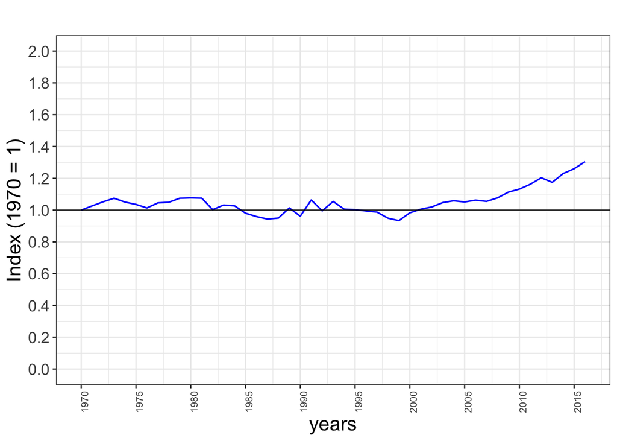

```r
canadian_index_newmethod = create_global_index_canada(combined_data)

# Make long version of taxo-region data (value for each year)
canadian_index = tidyr::pivot_longer(canadian_index_newmethod[-ncol(canadian_index_newmethod)], cols=starts_with(c("1", "2")), values_to = "LPI_final", names_to = "Year")
canadian_index$CI_high = canadian_index$LPI_final
canadian_index$CI_low = canadian_index$LPI_final
rownames(canadian_index) = canadian_index$Year

ggplot_lpi(canadian_index, line_col = "blue")
```

We can then sample (with replacement) from this large table to create boostrapped LPI indices. Here boostrap sampls are at the population level.

```r
# Let's try generating a thousand sampled LPIs (sampling populations with replacement)
indices = list()
N = 100
i = 1
for (i in 1:N) {
  print(sprintf("Sampling populations [%d of %d]", i, N))
  bootstrap_data = sample_n(combined_data, nrow(combined_data), replace = TRUE)
  index = create_global_index_canada(bootstrap_data)

  # Turn into usual LPI format for plotting (LPI_final, CI_high, CI_low, with rownames as years)
  index = tidyr::pivot_longer(index[-ncol(index)], cols=starts_with(c("1", "2")), values_to = "LPI_final", names_to = "Year")
  index$CI_high = global_index$LPI_final
  index$CI_low = global_index$LPI_final
  rownames(index) = index$Year
  indices[[i]] = index
}
names(indices) = 1:N
d <- rbindlist(indices, idcol = "sample")

# Save, just in case
fwrite(d, "pop_sampled_lpis.csv")
```

```r
d = fread("pop_sampled_lpis.csv")
sampled_lpi = d %>% group_by(Year) %>%
  summarise(
    mean = mean(LPI_final),
    upr = quantile(LPI_final, probs = 0.975),
    lwr = quantile(LPI_final, probs = 0.025)
  )
colnames(sampled_lpi) = c("Year", "LPI_final", "CI_high", "CI_low")
rownames(sampled_lpi) = sampled_lpi$Year
```

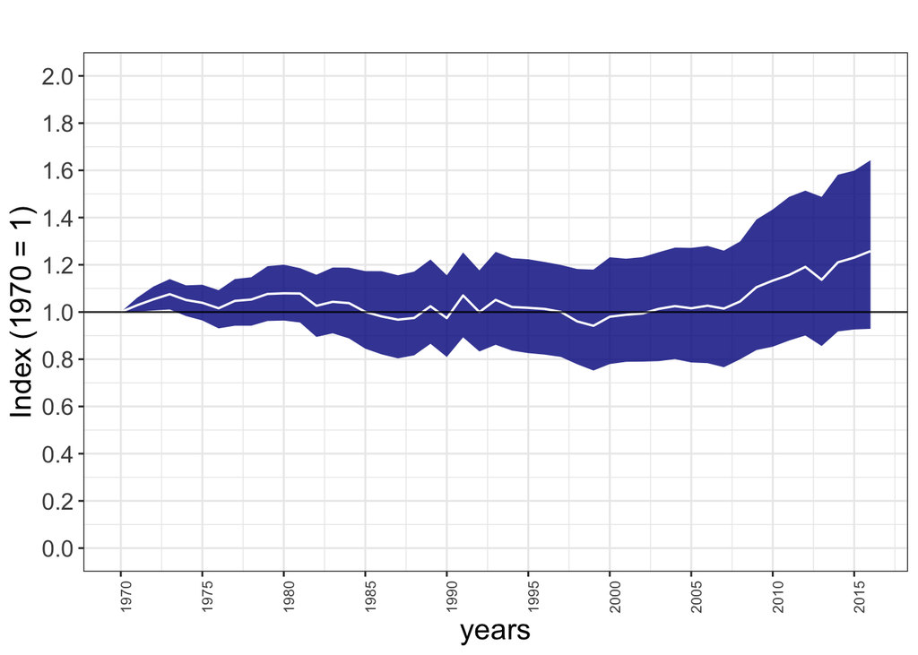

```r
ggplot_lpi(sampled_lpi, xlims = c(1970, 2016))
```

Similarly can sample at the species level…

```r
# Similarly, let's try sample species with replacement
species = unique(combined_data$Binomial)
indices_sp = list()
N = 100
i = 1
for (i in 1:N) {
  print(sprintf("Sampling populations [%d of %d]", i, N))
  sampled_species = sample(species, replace = TRUE)

  which(combined_data$Binomial %in% sampled_species[i])
  # Need to be careful here as we want all populations for a species, but perhaps multiple times if that
  # species has been selected twice ### This is very slow! Must be a better way
  bootstrap_data_idx <- unlist(lapply(sampled_species, function(sp) which(combined_data$Binomial %in% sp)))
  bootstrap_data = combined_data[bootstrap_data_idx, ]

  index = create_global_index_canada(bootstrap_data)

  # Turn into usual LPI format for plotting (LPI_final, CI_high, CI_low, with rownames as years)
  index = tidyr::pivot_longer(index[-ncol(index)], cols=starts_with(c("1", "2")), values_to = "LPI_final", names_to = "Year")
  index$CI_high = global_index$LPI_final
  index$CI_low = global_index$LPI_final
  rownames(index) = index$Year
  indices_sp[[i]] = index
}
names(indices_sp) = 1:N
d_sp <- rbindlist(indices_sp, idcol = "sample")

# Save, just in case
fwrite(d_sp, "sp_sampled_lpis.csv")
```

```r
d_sp = fread("sp_sampled_lpis.csv")
sampled_lpi_sp = d_sp %>% group_by(Year) %>%
  summarise(
    mean = mean(LPI_final),
    upr = quantile(LPI_final, probs = 0.975),
    lwr = quantile(LPI_final, probs = 0.025)
  )
colnames(sampled_lpi_sp) = c("Year", "LPI_final", "CI_high", "CI_low")
rownames(sampled_lpi_sp) = sampled_lpi_sp$Year
```

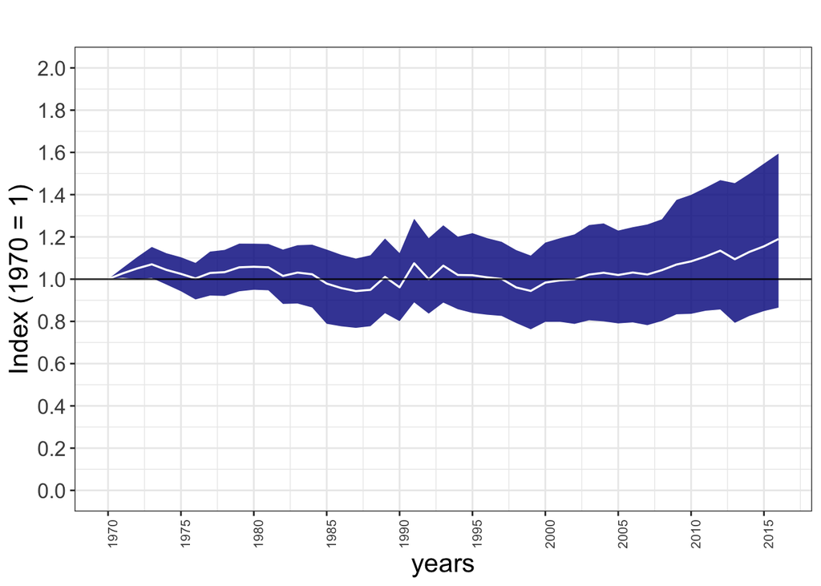

```r
ggplot_lpi(sampled_lpi_sp, xlims = c(1970, 2016))
```

## Making lambdas using rlpi for Canadian dataset

```r
library(rlpi)

# Load Canadian data
lpi_data <- read.csv("data/CIEE_LPI_dataset.csv", na.strings = "NA")

# Combine Binomial and ID (to ensure each population is treated as a unique species)
lpi_data$Binomial = paste(lpi_data$Binomial, lpi_data$ID, sep="_")

# Make an infile for all the data
infilename = create_infile(lpi_data, name = "all_canada_pops_poplevel.csv", start_col_name = "X1950", end_col_name = "X2020")

# Run the LPI to make lambdas
canadian_lpiu_poplevel = LPIMain(infilename, basedir = "canadian_poplevel", REF_YEAR = 1950, PLOT_MAX = 2020)

# This should make a file in the specified directory (candian_poplevel) with lambda data that we can load
pop_data = fread("canadian_poplevel/all_canada_pops_poplevel.csv_pops_lambda.csv")
```